# Multivariate statistics Project Alfonso Andres

Alfonso Andres

2023-01-03

## Introduction

In this brief project, we will utilize various statistical techniques in R across four distinct datasets to illustrate key methodologies in multivariate analysis. The approaches demonstrated include Principal Component Analysis (PCA), fitting Generalized Linear Models (GLM), and hierarchical clustering, among others

## Part 1: Pendigits. PCA

```r
##Read the dataset and download the corresponding libraries
www_ = 'https://www.mimuw.edu.pl/~noble/courses/MultivariateStatistics/data/pendigits.txt'
pendigits = read.csv(www_,header = FALSE, sep = ' ')
library(ggplot2)
library(tidyr)
library(dplyr)
pendigits <- pendigits[,1:17]
summary(pendigits)
```

```
##        V1               V2               V3               V4
##  Min.   :  0.00   Min.   :  0.00   Min.   :  0.00   Min.   :  0.00
##  1st Qu.:  6.00   1st Qu.: 76.00   1st Qu.: 20.00   1st Qu.: 72.00
##  Median : 32.00   Median : 89.00   Median : 40.00   Median : 91.00
##  Mean   : 38.81   Mean   : 85.12   Mean   : 40.61   Mean   : 83.77
##  3rd Qu.: 65.00   3rd Qu.:100.00   3rd Qu.: 58.00   3rd Qu.:100.00
##  Max.   :100.00   Max.   :100.00   Max.   :100.00   Max.   :100.00
##        V5               V6               V7               V8
##  Min.   :  0.00   Min.   :  0.00   Min.   :  0.00   Min.   :  0.0
##  1st Qu.: 18.00   1st Qu.: 49.00   1st Qu.: 28.00   1st Qu.: 23.0
##  Median : 53.00   Median : 71.00   Median : 53.50   Median : 43.0
##  Mean   : 49.77   Mean   : 65.57   Mean   : 51.22   Mean   : 44.5
##  3rd Qu.: 78.00   3rd Qu.: 86.00   3rd Qu.: 74.00   3rd Qu.: 64.0
##  Max.   :100.00   Max.   :100.00   Max.   :100.00   Max.   :100.0
##        V9              V10             V11              V12
##  Min.   :  0.00   Min.   :  0.0   Min.   :  0.00   Min.   :  0.00
##  1st Qu.: 29.00   1st Qu.:  7.0   1st Qu.: 23.00   1st Qu.: 11.00
##  Median : 60.00   Median : 33.0   Median : 73.00   Median : 30.00
##  Mean   : 56.87   Mean   : 33.7   Mean   : 60.52   Mean   : 34.83
##  3rd Qu.: 89.00   3rd Qu.: 54.0   3rd Qu.: 97.00   3rd Qu.: 55.00
##  Max.   :100.00   Max.   :100.0   Max.   :100.00   Max.   :100.00
##       V13              V14              V15              V16
##  Min.   :  0.00   Min.   :  0.00   Min.   :  0.00   Min.   :  0.00
##  1st Qu.: 42.00   1st Qu.:  5.00   1st Qu.:  0.00   1st Qu.:  0.00
##  Median : 53.00   Median : 27.00   Median : 40.00   Median :  9.00
##  Mean   : 55.02   Mean   : 34.94   Mean   : 47.29   Mean   : 28.85
##  3rd Qu.: 68.00   3rd Qu.: 47.00   3rd Qu.:100.00   3rd Qu.: 51.00
##  Max.   :100.00   Max.   :100.00   Max.   :100.00   Max.   :100.00
##       V17
##  Min.   :0.000
##  1st Qu.:2.000
##  Median :4.000
##  Mean   :4.432
##  3rd Qu.:7.000
##  Max.   :9.000
```

We first open the dataset to look at the variables

```r
##Computing the variance of the 17 variables to see their similarity
variance <-sapply(pendigits,var)
variance
```

```
##          V1          V2          V3          V4          V5          V6
## 1173.595672  263.042035  693.952813  367.245343 1162.845095  728.821144
##          V7          V8          V9         V10         V11         V12
##  934.945662  894.375033 1165.234377  742.646884 1390.401333  735.493418
##         V13         V14         V15         V16         V17
##  498.876311 1099.284727 1743.930994 1280.071975    8.276822
```

Variances are not very similar all together. However some of them are very alike in small groups

```r
##2
##Carriyng a PCA over the covariance matrix
pca<-prcomp(pendigits,scale = FALSE)
summary(pca)
```

```
## Importance of components:
##                            PC1     PC2     PC3      PC4      PC5      PC6
## Standard deviation     64.9132 60.8446 47.8152 36.62559 29.35995 26.80550
## Proportion of Variance  0.2831  0.2487  0.1536  0.09013  0.05792  0.04828
## Cumulative Proportion   0.2831  0.5319  0.6855  0.77562  0.83353  0.88181
##                             PC7      PC8      PC9     PC10     PC11     PC12
## Standard deviation     21.40269 19.94072 16.93503 14.31017 11.36388 10.01676
## Proportion of Variance  0.03078  0.02672  0.01927  0.01376  0.00868  0.00674
## Cumulative Proportion   0.91259  0.93931  0.95858  0.97234  0.98102  0.98776
##                           PC13    PC14    PC15    PC16    PC17
## Standard deviation     8.13948 7.66116 5.23505 4.94483 2.32702
## Proportion of Variance 0.00445 0.00394 0.00184 0.00164 0.00036
## Cumulative Proportion  0.99221 0.99615 0.99799 0.99964 1.00000
```

We compute the PCA With the prcomp command over the covariance matrix. summary gives the most important features of our PCA

```r
eigs <- pca$sdev^2
eigs / sum(eigs)
```

```
##  [1] 0.2831225091 0.2487442698 0.1536175679 0.0901317213 0.0579187106
##  [6] 0.0482787687 0.0307783445 0.0267171314 0.0192699445 0.0137593530
## [11] 0.0086768392 0.0067415977 0.0044514480 0.0039436464 0.0018414083
## [16] 0.0016429019 0.0003638378
```

If we want to have 80% of the data explained then we ought to take 5 variables. If we want 90% we have to take 7 variables.

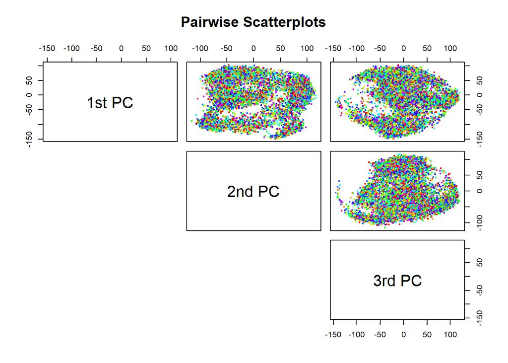

```r
pairs(data.frame(pca$x[,1], pca$x[,2], pca$x[,3]), lower.panel = NULL,
      labels = c('1st PC', '2nd PC', '3rd PC'), main = 'Pairwise Scatterplots',
      col = rainbow(10)[pendigits$V17], pch = 19,  cex = 0.4)
```

We scatterplot the values 2 by 2 With the pairwise plot.

```r
corpendigits<-cor(pendigits)
pcacor<-prcomp(corpendigits)
summary(pcacor)
```

```
## Importance of components:
##                           PC1    PC2    PC3    PC4     PC5     PC6     PC7
## Standard deviation     1.1731 0.8020 0.6587 0.3152 0.27279 0.22032 0.17968
## Proportion of Variance 0.5001 0.2337 0.1577 0.0361 0.02704 0.01764 0.01173
## Cumulative Proportion  0.5001 0.7338 0.8915 0.9276 0.95468 0.97232 0.98405
##                           PC8     PC9    PC10    PC11    PC12    PC13    PC14
## Standard deviation     0.1483 0.10139 0.08077 0.05559 0.03355 0.02229 0.01511
## Proportion of Variance 0.0080 0.00374 0.00237 0.00112 0.00041 0.00018 0.00008
## Cumulative Proportion  0.9920 0.99578 0.99815 0.99928 0.99969 0.99987 0.99995
##                            PC15    PC16      PC17
## Standard deviation     0.009484 0.00713 1.484e-17
## Proportion of Variance 0.000030 0.00002 0.000e+00
## Cumulative Proportion  0.999980 1.00000 1.000e+00
```

We know that for the correletion matrix ${M}$ $m_{ij}\in[-1,1]$. The pca standar deviations are therefore much smaller and so are the eigenvalues.

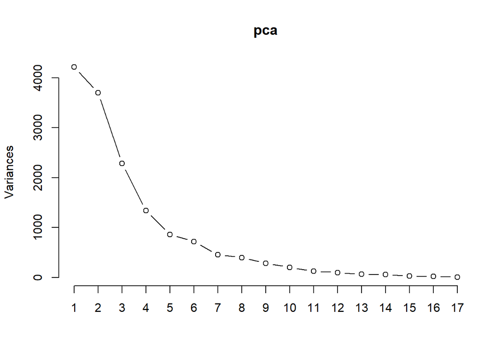

```r
screeplot(pca,type = 'lines',npcs = 17)
```

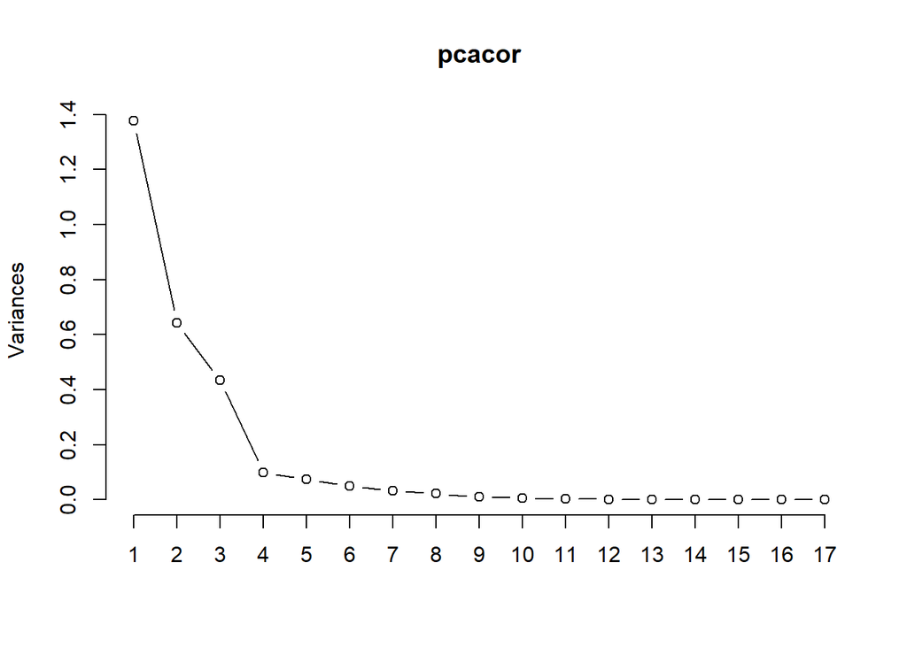

```r
screeplot(pcacor,type='lines',npcs = 17)
```

For both PCA the elbow comes with the 4 principal component approximately

There are some variables that are not very significant in the PCA, therefore there could be some problems when trying to invert $XX^T$. There is ill-conditioning in the data matrix

## Part 2: Ozone levels. Correlation test

```r
library('ade4')
library('kohonen')

www3 = "https://www.mimuw.edu.pl/~noble/courses/MultivariateStatistics/data/ozone.csv"
ozone = read.csv(www3,header= T)
station.dists <- dist(cbind(ozone$Lon, ozone$Lat))
ozone.dists <- dist(ozone$Av8top)
mantel.rtest(station.dists, ozone.dists, nrepet = 2000)
```

```
## Monte-Carlo test
## Call: mantel.rtest(m1 = station.dists, m2 = ozone.dists, nrepet = 2000)
##
## Observation: 0.1636308
##
## Based on 2000 replicates
## Simulated p-value: 0.03298351
## Alternative hypothesis: greater
##
##     Std.Obs Expectation    Variance
## 2.154381624 0.003816056 0.005502859
```

This result tells us that both matrices are related. We reject the null hypothesis with a level of significance $\alpha=0.05$.

## Part 3: Primate data. Hierarchical clustering

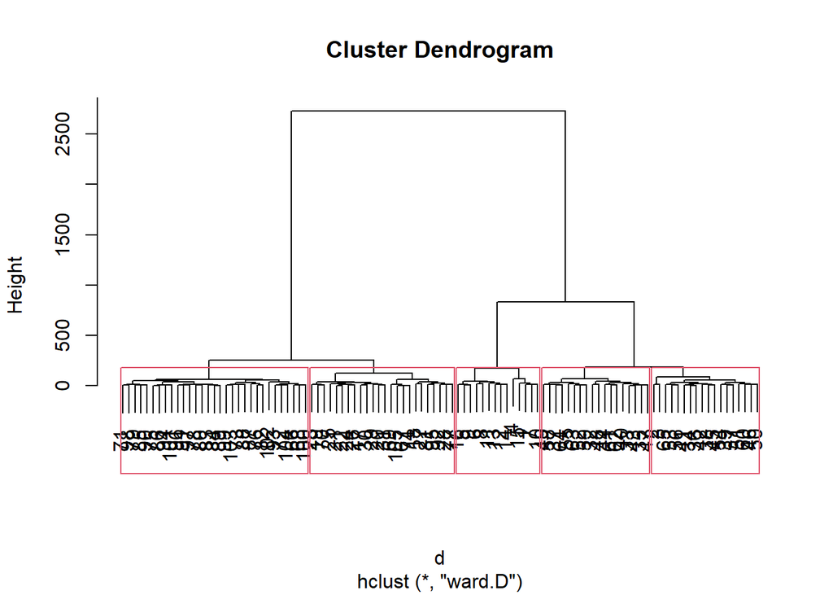

```r
library(cluster)
wwwpr = 'https://www.mimuw.edu.pl/~noble/courses/MultivariateStatistics/data/primate.scapulae.txt'
primate = read.csv(wwwpr,header = T,sep = " ",quote = "")
scaleprimate<- scale(primate[,2:8])
d <-dist(primate[,2:8])
ward <-hclust(d,method = 'ward.D')##Compute the hierarchical clustering with the ward linkage
plot(ward)
wardclust <-rect.hclust(ward,k = 5)
```

The ward method is robust against outliers

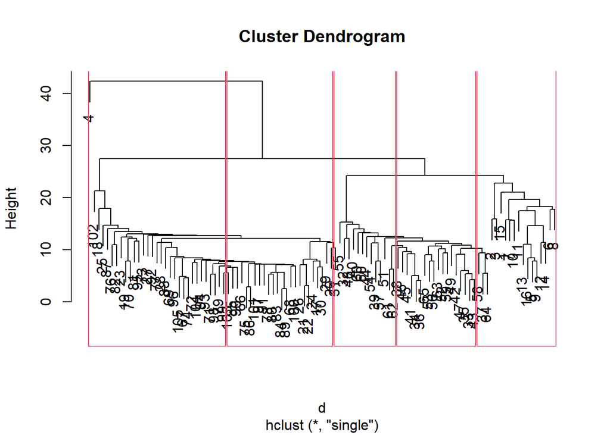

```r
single <-hclust(d,method = 'single')
plot(single)
singleclust <-rect.hclust(ward,k = 5)
```

We can see that single method returns outliers

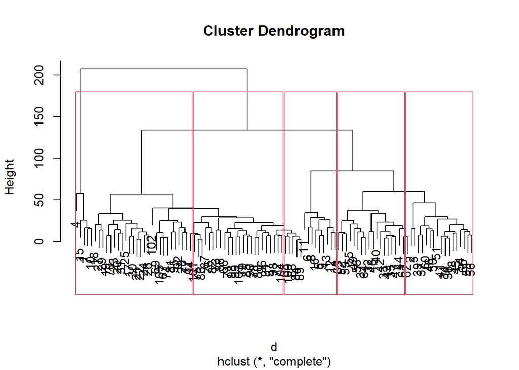

```r
complete<-hclust(d,method = 'complete')
plot(complete)
completeclust <-rect.hclust(ward,k = 5)
```

Complete linkage does not return outliers

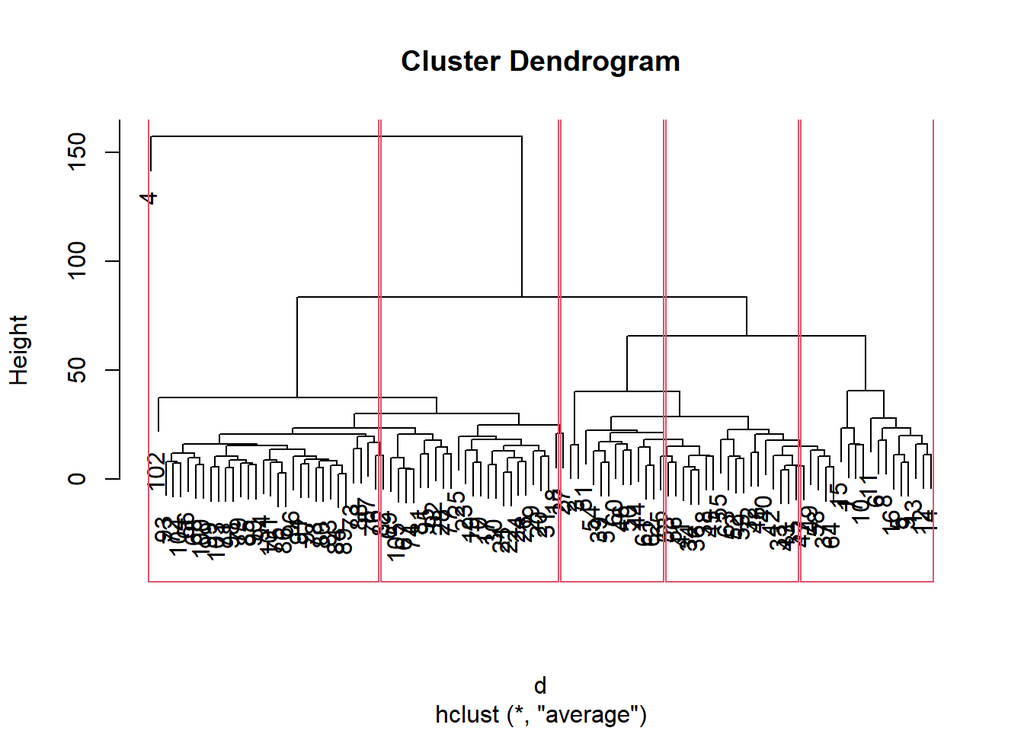

```r
average<-hclust(d,method = 'average')
plot(average)
averageclust <-rect.hclust(ward,k = 5)
```

We can see that average method gives outliers

```r
divisive<-diana(primate[2:8])
j<-pltree(divisive)
divclust <-rect.hclust(divisive,k = 2)
```

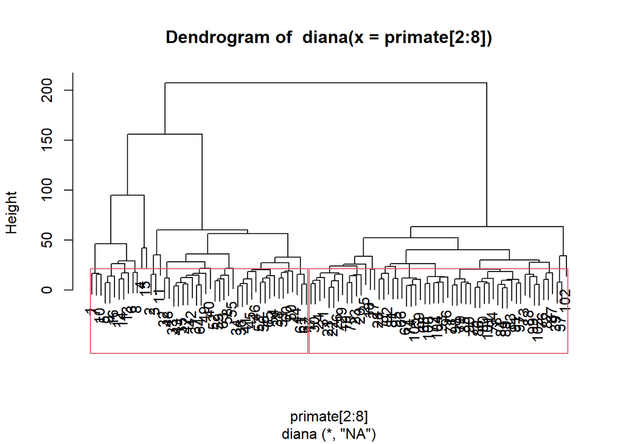

The divisive method forms clusters by dividing the data from one initial cluster that gathers the entire dataset. This method does not generate outliers

Computing all possibilities this is the one that better adjusts to a good clustering for each of the four methods

```
#> ward.D linkage
#>
#>
#> Prediction  Gorilla Homo Hylobates Pan Pongo
#>   Gorilla         0    4         2   0     2
#>   Homo            0   35         0   0     0
#>   Hylobates       0    0        14   0     0
#>   Pan            14    0         0  20     0
#>   Pongo           0    1         0   0    13
#>
#>  Accuracy
#> 0.7809524
```

```r
#>single linkage
```

```
#>
#>
#> Prediction  Gorilla Homo Hylobates Pan Pongo
#>   Gorilla         0    0         0   0     1
#>   Homo            0   39         0   0    13
#>   Hylobates       0    1         0   0     0
#>   Pan            14    0        16  20     0
#>   Pongo           0    0         0   0     1
#>
#>  Accuracy
#> 0.5714286
#>
#>
#>
#>
#>  complete linkage
#>
#>
#> Prediction  Gorilla Homo Hylobates Pan Pongo
#>   Gorilla         0    4         2   0     2
#>   Homo            0   35         0   0     0
#>   Hylobates       0    0        14   0     0
#>   Pan            14    0         0  20     0
#>   Pongo           0    1         0   0    13
#>
#>  Accuracy
#> 0.7809524
#>
#>
#> average linkage
#>
#>
#> Prediction  Gorilla Homo Hylobates Pan Pongo
#>   Gorilla         0    0         0   0     1
#>   Homo            0   36         0   0    13
#>   Hylobates       0    0        16   0     0
#>   Pan            14    0         0  20     0
#>   Pongo           0    4         0   0     1
#>
#>  Accuracy
#> 0.6952381
```

The ward and complete linkage perform equally good.They have the highest and same rating;that is why they are the optimal linkage to use for this particular case. Single and average leave out some important points and have lower rating. Single has the lowest

## Part 4: Doctor visits. GLM model

```r
library(AER)
library('MASS')
data('DoctorVisits')
poisson <-glm(visits~.,data = DoctorVisits,family=poisson())
poisson
```

```
##
## Call:  glm(formula = visits ~ ., family = poisson(), data = DoctorVisits)
##
## Coefficients:
##  (Intercept)  genderfemale           age        income       illness
##     -2.09782       0.15649       0.27912      -0.18742       0.18616
##      reduced        health    privateyes   freepooryes  freerepatyes
##      0.12669       0.03068       0.12650      -0.43846       0.08364
##  nchronicyes   lchronicyes
##      0.11730       0.15072
##
## Degrees of Freedom: 5189 Total (i.e. Null);  5178 Residual
## Null Deviance:       5635
## Residual Deviance: 4380  AIC: 6736
```

```r
coeftest(poisson)
```

```
##
## z test of coefficients:
##
##                Estimate Std. Error  z value  Pr(>|z|)
## (Intercept)  -2.0978213  0.1015537 -20.6573 < 2.2e-16 ***
## genderfemale  0.1564897  0.0561390   2.7875  0.005311 **
## age           0.2791232  0.1659812   1.6817  0.092636 .
## income       -0.1874159  0.0854784  -2.1926  0.028340 *
## illness       0.1861564  0.0182629  10.1932 < 2.2e-16 ***
## reduced       0.1266904  0.0050307  25.1836 < 2.2e-16 ***
## health        0.0306832  0.0100738   3.0459  0.002320 **
## privateyes    0.1264980  0.0715518   1.7679  0.077074 .
## freepooryes  -0.4384619  0.1797987  -2.4386  0.014743 *
## freerepatyes  0.0836398  0.0920697   0.9084  0.363646
## nchronicyes   0.1172997  0.0665454   1.7627  0.077951 .
## lchronicyes   0.1507172  0.0822598   1.8322  0.066920 .
## ---
## Signif. codes:  0 '***' 0.001 '**' 0.01 '*' 0.05 '.' 0.1 ' ' 1
```

```r
dispersiontest(poisson)
```

```
##
##  Overdispersion test
##
## data:  poisson
## z = 6.5386, p-value = 3.105e-11
## alternative hypothesis: true dispersion is greater than 1
## sample estimates:
## dispersion
##   1.415602
```

Variables age, privateyes, freerepatres, nchronicyes and lchronicyes are less important. They dont have the same estimation

```r
dispersiontest(poisson)
```

```
##
##  Overdispersion test
##
## data:  poisson
## z = 6.5386, p-value = 3.105e-11
## alternative hypothesis: true dispersion is greater than 1
## sample estimates:
## dispersion
##   1.415602
```

since $\alpha>0$ there is overdispersion. To handle this we will use a negativeBinomial regression to compare both models related to the number of visits

```r
negbin_re<-glm.nb(visits~.,data=DoctorVisits)
coeftest(negbin_re)
```

```
##
## z test of coefficients:
##
##                Estimate Std. Error  z value  Pr(>|z|)
## (Intercept)  -2.2761376  0.1227494 -18.5430 < 2.2e-16 ***
## genderfemale  0.2163334  0.0696815   3.1046  0.001905 **
## age           0.3313261  0.2077554   1.5948  0.110759
## income       -0.1562137  0.1039067  -1.5034  0.132735
## illness       0.2149366  0.0235211   9.1380 < 2.2e-16 ***
## reduced       0.1437288  0.0073053  19.6745 < 2.2e-16 ***
## health        0.0375351  0.0136086   2.7582  0.005812 **
## privateyes    0.1163786  0.0856660   1.3585  0.174300
## freepooryes  -0.4972564  0.2106959  -2.3601  0.018272 *
## freerepatyes  0.1456834  0.1158512   1.2575  0.208571
## nchronicyes   0.0979055  0.0791533   1.2369  0.216121
## lchronicyes   0.1834730  0.1031764   1.7782  0.075364 .
## ---
## Signif. codes:  0 '***' 0.001 '**' 0.01 '*' 0.05 '.' 0.1 ' ' 1
```

```r
logLik(poisson)
```

```
## 'log Lik.' -3355.85 (df=12)
```

```r
logLik(negbin_re)
```

```
## 'log Lik.' -3198.838 (df=13)
```